# Loan Data from Prosper

## Preliminary Wrangling

> This data set is downloaded from Udacity. Originally it was from Prosper, America’s first marketplace lending platform, with over $9 billion in funded loans. This project is reasearching on the possible features that affect the borrower’s APR or interest rate.

# Set Up

```python
# import all packages and set plots to be embedded inline
import numpy as np
import pandas as pd
import matplotlib.pyplot as plt
import seaborn as sb
import urllib
%matplotlib inline
import os

# create sub folders for images, data
IMAGE_DIR = os.path.join('.', 'IMAGE')
DATA_DIR = os.path.join('.', 'DATA')
if not os.path.isdir(IMAGE_DIR):
    os.mkdir(IMAGE_DIR)
if not os.path.isdir(DATA_DIR):
    os.mkdir(DATA_DIR)

# save figure
def save_fig(name, path=IMAGE_DIR, dpi=300, format='png'):
    """Save figure into designatred foler, given figure name and path."""

    file_path = os.path.join(IMAGE_DIR, name+'.'+format)
    plt.savefig(file_path, dpi=dpi)

# fetch data from udacity amazon s3
def fetch_data(dataurl, filename, path=DATA_DIR, format='csv'):
    """Fetch data from the provided link.
    Save the data with customized name and destination.
    """

    file_path = os.path.join(DATA_DIR, filename+'.'+format)
    urllib.request.urlretrieve(dataurl, file_path)
    print('Data downloaded in: ', file_path)
```

# Load Data

```python
dataurl = 'https://s3.amazonaws.com/udacity-hosted-downloads/ud651/prosperLoanData.csv'
fetch_data(dataurl, filename='prosperLoadData')
```

```
Data downloaded in:  .\DATA\prosperLoadData.csv
```

```python
df = pd.read_csv('DATA\prosperLoadData.csv')
df.info()
```

```
<class 'pandas.core.frame.DataFrame'>
RangeIndex: 113937 entries, 0 to 113936
Data columns (total 81 columns):
 #   Column                               Non-Null Count   Dtype
---  ------                               --------------   -----
 0   ListingKey                           113937 non-null  object
 1   ListingNumber                        113937 non-null  int64
 2   ListingCreationDate                  113937 non-null  object
 3   CreditGrade                          28953 non-null   object
 4   Term                                 113937 non-null  int64
 5   LoanStatus                           113937 non-null  object
 6   ClosedDate                           55089 non-null   object
 7   BorrowerAPR                          113912 non-null  float64
 8   BorrowerRate                         113937 non-null  float64
 9   LenderYield                          113937 non-null  float64
```

[output cut: 73 more lines]

```python
df.head(3)
```

|  | ListingKey | ListingNumber | ListingCreationDate | CreditGrade | Term | LoanStatus | ClosedDate | BorrowerAPR | BorrowerRate | LenderYield | ... | LP_ServiceFees | LP_CollectionFees | LP_GrossPrincipalLoss | LP_NetPrincipalLoss | LP_NonPrincipalRecoverypayments | PercentFunded | Recommendations | InvestmentFromFriendsCount | InvestmentFromFriendsAmount | Investors |
| --- | --- | --- | --- | --- | --- | --- | --- | --- | --- | --- | --- | --- | --- | --- | --- | --- | --- | --- | --- | --- | --- |
| 0 | 1021339766868145413AB3B | 193129 | 2007-08-26 19:09:29.263000000 | C | 36 | Completed | 2009-08-14 00:00:00 | 0.16516 | 0.158 | 0.138 | ... | -133.18 | 0.0 | 0.0 | 0.0 | 0.0 | 1.0 | 0 | 0 | 0.0 | 258 |
| 1 | 10273602499503308B223C1 | 1209647 | 2014-02-27 08:28:07.900000000 | NaN | 36 | Current | NaN | 0.12016 | 0.092 | 0.082 | ... | 0.00 | 0.0 | 0.0 | 0.0 | 0.0 | 1.0 | 0 | 0 | 0.0 | 1 |
| 2 | 0EE9337825851032864889A | 81716 | 2007-01-05 15:00:47.090000000 | HR | 36 | Completed | 2009-12-17 00:00:00 | 0.28269 | 0.275 | 0.240 | ... | -24.20 | 0.0 | 0.0 | 0.0 | 0.0 | 1.0 | 0 | 0 | 0.0 | 41 |

3 rows × 81 columns

```python
#subset dataframe by selecting features of interests

cols = ['BorrowerAPR', 'ProsperScore', 'DelinquenciesLast7Years','StatedMonthlyIncome',
        'AvailableBankcardCredit', 'CreditScoreRangeUpper', 'LoanOriginalAmount',
        'Term', 'ProsperRating (Alpha)', 'EmploymentStatus', 'Occupation', 'LoanStatus']

loan = df[cols]
```

### What is the structure of your dataset?

> This dataset has 113937 entries, 81 columns. It consists of multiple data types, including numerical data, categorical data.

### What is/are the main feature(s) of interest in your dataset?

> I am interested in the features that affect the borrower’s APR or interest rate.

### What features in the dataset do you think will help support your investigation into your feature(s) of interest?

> The Prosper Score is expected to have negative relation with ARP, because higher rating reflects borrower's good credit history or lower risk. When borrower has strong credibility, the interest rate is low. Additionally, other factors such as borrower's occupation, origional load amount, contract term, monthly income may also affect their APR.

## Univariate Exploration

- main variable of interest: borrower APR

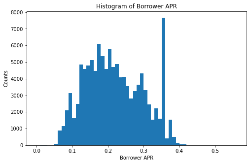

```python
bins = np.arange(0, loan.BorrowerAPR.max()+0.05, 0.01)
plt.figure(figsize=(8, 5))
plt.hist(data = loan, x = 'BorrowerAPR', bins = bins);
plt.xlabel('Borrower APR')
plt.title('Histogram of Borrower APR')
plt.ylabel('Counts')
save_fig('Borrower_APR');
```

The distribution of APR looks normal except for a starggering peak round 0.35 to 0.37. A large peak centered at 0.2. Only very few loans have APR greater than 0.43.

```python
loan[loan['BorrowerAPR']>=0.43]
```

|  | BorrowerAPR | ProsperScore | DelinquenciesLast7Years | StatedMonthlyIncome | AvailableBankcardCredit | CreditScoreRangeUpper | LoanOriginalAmount | Term | ProsperRating (Alpha) | EmploymentStatus | Occupation | LoanStatus |
| --- | --- | --- | --- | --- | --- | --- | --- | --- | --- | --- | --- | --- |
| 18326 | 0.45857 | NaN | NaN | 10000.000000 | NaN | NaN | 3000 | 36 | NaN | NaN | NaN | Defaulted |
| 22195 | 0.46201 | NaN | NaN | 2916.666667 | NaN | NaN | 1789 | 36 | NaN | NaN | NaN | Chargedoff |
| 36018 | 0.51229 | NaN | NaN | 2838.000000 | NaN | NaN | 1500 | 36 | NaN | NaN | NaN | Completed |
| 56761 | 0.50633 | NaN | NaN | 0.000000 | NaN | NaN | 3000 | 36 | NaN | NaN | NaN | Defaulted |
| 82043 | 0.48873 | NaN | NaN | 1583.333333 | NaN | NaN | 3000 | 36 | NaN | NaN | NaN | Defaulted |
| 103973 | 0.45857 | NaN | NaN | 3750.000000 | NaN | NaN | 2800 | 36 | NaN | NaN | NaN | Defaulted |

The 6 borrowers with largest APR have small loan amount and a 3 year contract term. They don't have records of Prosper rating and employment status. If we have stronger evidence these record don't make sense, we should discard them from our data. But so far I cannot be confident in it. I will keep them in my analysis.

- Prosper Score

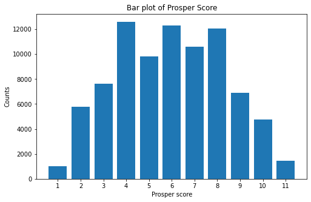

```python
arr = loan['ProsperScore'].value_counts(sort=False)
plt.figure(figsize=(8, 5))
plt.bar(arr.index, arr.values)
plt.xticks(range(1, 12), range(1,12))
plt.xlabel('Prosper score')
plt.title('Bar plot of Prosper Score')
plt.ylabel('Counts')
save_fig('Prosper_Score');
```

Majority of the prosper scores range from 4 to 8. In particular, the most popular scores are 4, 6, 8.

- Occupation

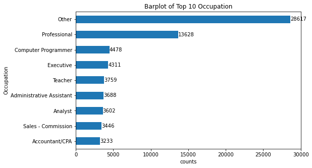

```python
arr = loan['Occupation'].value_counts(ascending=True)[-9:]
arr.plot(kind='barh', figsize=(8, 5))
for i, v in enumerate(arr):
    plt.text(v+0.1, i-0.1, str(v))
plt.xlabel('counts')
plt.ylabel('Occupation')
plt.title('Barplot of Top 10 Occupation')
save_fig('Occupation_plot');
```

The top 2 occupation categories are "others" or "professional". These might be entered when people do not want to reveal their occupation. Other categories do not show a significant spike in the proportion.

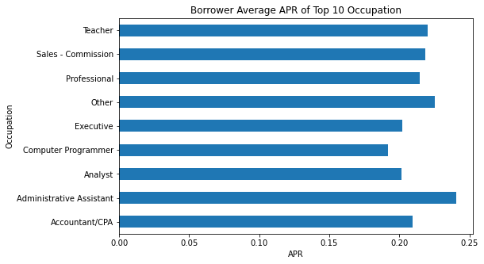

```python
group = loan.groupby('Occupation')['BorrowerAPR'].mean()
group = group.loc[group.index.isin(arr.index)]
group.plot(kind='barh', figsize=(8, 5))
plt.xlabel('APR')
plt.title('Borrower Average APR of Top 10 Occupation')
save_fig('APR_by_Occupation')
```

Interestingly, administrative assistant has the highest interest rate than the other occupation. On the contrary, being a computer programmer seems to be favored by the loan company with lower interest rate. I wonder if it has anything to do with their income.

- Monthly Income

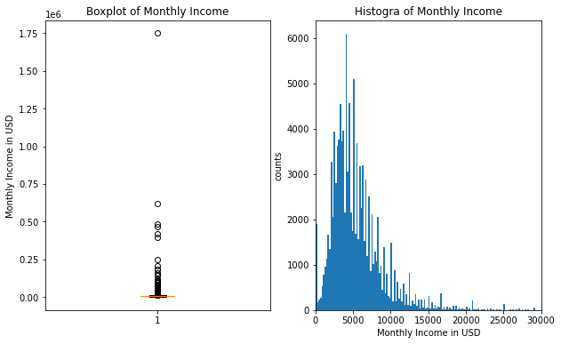

```python
fig, (ax1, ax2) = plt.subplots(1, 2, figsize=(10, 6))

ax1.boxplot(loan['StatedMonthlyIncome'])
ax1.set(title='Boxplot of Monthly Income', ylabel='Monthly Income in USD', xlabel=None)
bins=np.arange(0, loan['StatedMonthlyIncome'].max()+10, 200)
ax2.hist(data=loan, x='StatedMonthlyIncome', bins=bins)
ax2.set(title='Histogra of Monthly Income', ylabel='counts', xlabel='Monthly Income in USD')
plt.xlim([0, 30000])

save_fig('Monthly_Income');
```

The distribution of stated monthly income is highly screwed to the right, with most of stated monthly income less than 25k. A large number of outliers are seen in the upper range.

```python
#proportions of income larger than 30k
loan[loan['StatedMonthlyIncome']>30000].size/len(loan)
```

```
0.03157007820111114
```

Only 0.3% of the people have income greater than 30k. How much is their loan amount?

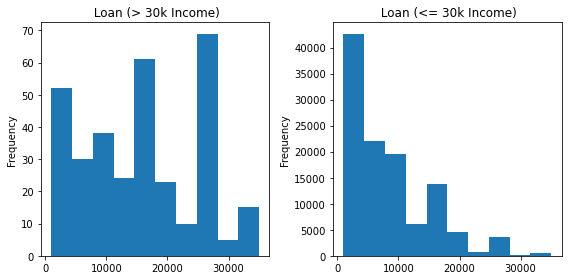

```python
income_30kplus = loan[loan['StatedMonthlyIncome']>30000]
income_30kminus = loan[loan['StatedMonthlyIncome']<=30000]

plt.subplot(1,2, 1)
income_30kplus['LoanOriginalAmount'].plot(kind='hist', figsize=(8, 4))
plt.title(' Loan (> 30k Income)')
plt.subplot(1,2,2)
income_30kminus['LoanOriginalAmount'].plot(kind='hist')
plt.title(' Loan (<= 30k Income)')
plt.tight_layout()
save_fig('Loan_By_Income')
```

The distribution of loaning amount among 30k+ income group and 30k- income group are quite different. The 30k+ appears to have multimodal distribution, with a few spikes, while the 30k- income group skewed to the right.

```python
# those with 100k income but borrow for less than 5k
mask = (income_30kplus['StatedMonthlyIncome']>100000) & (income_30kplus['LoanOriginalAmount'] < 5000)
strange_rich = income_30kplus[mask]
strange_rich
```

|  | BorrowerAPR | ProsperScore | DelinquenciesLast7Years | StatedMonthlyIncome | AvailableBankcardCredit | CreditScoreRangeUpper | LoanOriginalAmount | Term | ProsperRating (Alpha) | EmploymentStatus | Occupation |
| --- | --- | --- | --- | --- | --- | --- | --- | --- | --- | --- | --- |
| 8066 | 0.35643 | 4.0 | 2.0 | 4.166667e+05 | 0.0 | 679.0 | 2000 | 36 | HR | Employed | Police Officer/Correction Officer |
| 35218 | 0.07389 | 10.0 | 0.0 | 1.083333e+05 | 44683.0 | 879.0 | 1000 | 36 | AA | Full-time | Attorney |
| 45028 | 0.33973 | 2.0 | 0.0 | 1.500000e+05 | 2089.0 | 639.0 | 4000 | 36 | E | Self-employed | Nurse (RN) |
| 53014 | 0.25785 | 3.0 | 3.0 | 6.185478e+05 | 3091.0 | 739.0 | 4000 | 12 | D | Self-employed | Other |
| 53167 | 0.35797 | 4.0 | 0.0 | 1.750003e+06 | 26168.0 | 759.0 | 4000 | 36 | HR | Self-employed | Professional |
| 57133 | 0.35643 | 5.0 | 0.0 | 4.666667e+05 | 0.0 | 699.0 | 4000 | 36 | E | Employed | Other |
| 63925 | 0.25948 | NaN | 0.0 | 1.404167e+05 | NaN | 579.0 | 2000 | 36 | NaN | Not available | Retail Management |
| 82831 | 0.31012 | 3.0 | 0.0 | 2.500000e+05 | 2331.0 | 719.0 | 4000 | 36 | E | Self-employed | Other |
| 113270 | 0.22712 | 6.0 | 0.0 | 3.944000e+05 | 10012.0 | 699.0 | 2000 | 36 | C | Employed | Other |

Suprisingly, the richest person with 1.75 million income borrowed only 4000 from the loan institute. There are in total 9 persons have 100k income, but borrow for less than 5k. These data seemed to be mistake.

- Other features

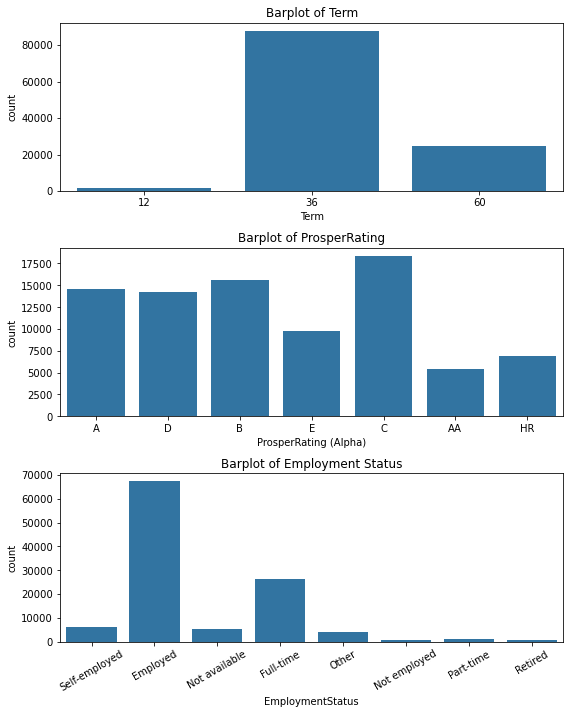

```python
default_color = sb.color_palette()[0]

fig, ax = plt.subplots(3, 1, figsize=(8, 10))
sb.countplot(data = loan, x = 'Term', color = default_color, ax = ax[0])
sb.countplot(data = loan, x = 'ProsperRating (Alpha)', color = default_color, ax = ax[1])
sb.countplot(data = loan, x = 'EmploymentStatus', color = default_color, ax = ax[2]);
ax[0].set(title='Barplot of Term')
ax[1].set(title='Barplot of ProsperRating')
ax[2].set(title='Barplot of Employment Status')
plt.xticks(rotation=30)
plt.tight_layout(True)
save_fig('Counts of Others');
```

The first plot shows the majority of the contracts last for 36 months.The secon plot shows most of the borrowers are among A to D. The last plot shows most of the borrowers are employed and full-time.

### Discuss the distribution(s) of your variable(s) of interest. Were there any unusual points? Did you need to perform any transformations?

The distribution of APR looks normal except for a starggering peak round 0.35 to 0.37. A large peak centered at 0.2. Most of the values are at the range of 0.05 and 0.4. There are no unusual points and no need to perform any transformations.

Suprisingly, the richest person with 1.75 million income borrowed only 4000 from the loan institute. There are in total 9 persons have 100k income, but borrow for less than 5k. These data seemed to be mistake. In addition, the very rich people over 30k income are outliers in our dataset judged from the boxplot. To mitigate bias, we discard these outliers, overall 0.3% from our dataset.

### Of the features you investigated, were there any unusual distributions? Did you perform any operations on the data to tidy, adjust, or change the form of the data? If so, why did you do this?

The distributions of stated monthly income is highly right screwed. Most stated monthly incomes are less than 30k. Surprisingly, there are 9 people with 100k+ monthly income only loan less than 5k dollars. This is more likely to be mistake in the income. We can either transform the income to square root, hoping it will become normal distribution for next step analysis. But it will also keep those mistakes in our data. So to mitigate bias, I discard those data whose income is large than 30k. Overall, only 0.3% of borrowers have started monthly income greater than 30k.

```python
# exclude the strange rich people who borrow very little amount
mask = (loan['StatedMonthlyIncome']< 30000)
loan = loan[mask]
```

## Bivariate Exploration

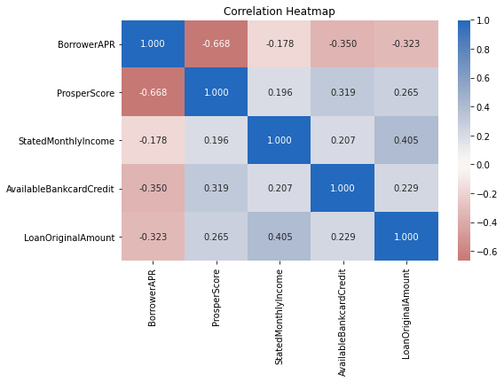

```python
# correlation plot

num_vars = ['BorrowerAPR', 'ProsperScore', 'StatedMonthlyIncome', 'AvailableBankcardCredit', 'LoanOriginalAmount']

plt.figure(figsize = [8, 5])
sb.heatmap(loan[num_vars].corr(), annot = True, fmt = '.3f', cmap = 'vlag_r', center = 0)
plt.title('Correlation Heatmap')
save_fig('Numerical_Correlation')
```

[figure not shown]

```python
# plot matrix: sample 5000 loans so that plots are clearer and render faster
loan_sample = loan.sample(5000)
g = sb.PairGrid(data = loan_sample.dropna(), vars = num_vars)
g = g.map_diag(plt.hist, bins=20)
g.map_offdiag(sb.regplot)
save_fig('Numerical_Correlatin_Pair');
```

The largest correlation pair is the borrower APR and prosper score, with negative correlation coefficient of -0.668. It matches our assumption that the higher the prosper score, the lower risk the candidate, hence the lower interest rate. The scatter plot showed those two variables are negatively correlated. Similarly, higher BankCardCredit means the borrowers are more trustworthy, therefore it recevied lower APR. The heatmap below makes it clearer.

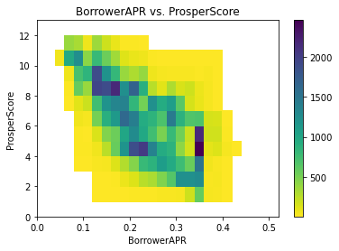

```python
bins_x = np.arange(0, loan['BorrowerAPR'].max()+0.01, 0.02)
bins_y = np.arange(0, loan['ProsperScore'].max()+3, 1)
plt.hist2d(data = loan, x = 'BorrowerAPR', y = 'ProsperScore', bins = [bins_x, bins_y], cmap = 'viridis_r', cmin = 0.3)
plt.colorbar()
plt.title('BorrowerAPR vs. ProsperScore')
plt.xlabel('BorrowerAPR')
plt.ylabel('ProsperScore');
```

- Employment Status vs Term

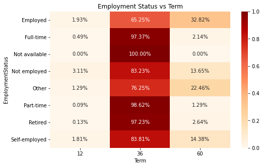

```python
emp_term = pd.crosstab(index=loan['EmploymentStatus'], columns=loan['Term'], normalize='index')
plt.figure(figsize=(8, 5))
sb.heatmap(emp_term, annot=True, fmt='.2%', cmap='OrRd')
plt.title('Employment Status vs Term');
```

- Prosper Rating vs. BorrowerRate

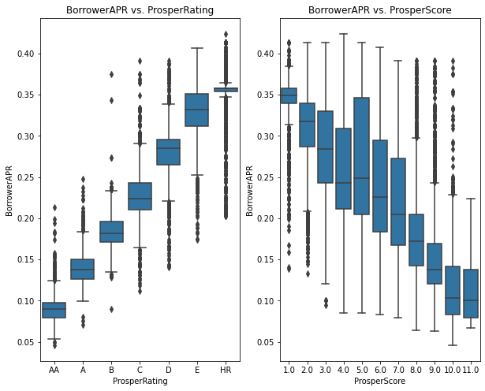

```python
plt.figure(figsize = (15, 5))

base_color=sb.color_palette()[0]
plt.subplot(1, 2, 1)
sb.boxplot(data = loan, x = 'ProsperRating (Alpha)', y = 'BorrowerAPR', color=base_color,
           order=['AA', 'A', 'B', 'C', 'D', 'E', 'HR'])
plt.gcf().set_size_inches(10, 8)
plt.title('BorrowerAPR vs. ProsperRating')
plt.xlabel('ProsperRating')
plt.ylabel('BorrowerAPR')

plt.subplot(1, 2, 2)
sb.boxplot(data = loan, x = 'ProsperScore', y = 'BorrowerAPR', color=base_color)
plt.gcf().set_size_inches(10, 8)
plt.title('BorrowerAPR vs. ProsperScore')
plt.xlabel('ProsperScore')
plt.ylabel('BorrowerAPR')
save_fig('Prosper_Score_and_Rating_vs_APR', dpi=600);
```

The plot shows strong correlation among prosper rating vs borrower's rate, prosper score vs borrower’s rate. The prsper rating is similar to the prosper score, except that it is represented in alphabet instead of numerical value. According to the provided data description:

> "0 - N/A, 1 - HR, 2 - E, 3 - D, 4 - C, 5 - B, 6 - A, 7 - AA. Applicable for loans originated after July 2009"

We can see that the lower the rating goes, the higher borrower's rate. This pattern is aligned with the prosper score boxplot on the right.

### Did you observe any interesting relationships between the other features (not the main feature(s) of interest)?

Employed borrowers are likely to select long term contract such as 3 or 5 years loan. Retirement and part-time borrowers are in favor of 3-year loan term. For those unemployed, there is a significant portion in favor of 5-year loan term.

## Multivariate Exploration

- Borrower APR across rating and term

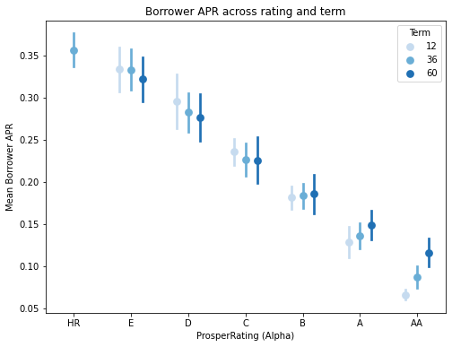

```python
fig = plt.figure(figsize = (8,6))
ax = sb.pointplot(data = loan, x = 'ProsperRating (Alpha)', y = 'BorrowerAPR', hue = 'Term',
           palette = 'Blues', linestyles = '', dodge = 0.4, ci='sd', order=['HR', 'E', 'D', 'C', 'B', 'A', 'AA'])
plt.title('Borrower APR across rating and term')
plt.ylabel('Mean Borrower APR')
ax.set_yticklabels([],minor = True)
save_fig('Borrower_APR_across_rating_and_term');
```

Above point plot shows borrower APR perentage decrease along with the increase of prosper rating (AA is the largest rating).

Within each rating, we can see three vertical lines, representing three term durations. From rating HR to C, the three vertical lines are going downward in each rating, but from B to AA, the trend becomes upward. For people with high prosper rating range (B to AA), the longer contract they take, the higher APR percentage they will receive. For people with low prosper rating range (HR to C), the longer contract they sign up, the lower ARP rate they will receive.

- Loan Status by Occupation and Income

We first group the loan status into 'Non-Performing', i.e. defaulted, chargedoff loan, and 'Performing' group. After that, we check the Non-Performing (NPF) rate by occupation and its average income.

```python
non_performing_mask = loan['LoanStatus'].isin(['Defaulted', 'Chargedoff'])
non_perf = loan[non_performing_mask].groupby('Occupation')['LoanStatus'].size().to_frame('NPF_Counts')
perf = loan[~non_performing_mask].groupby('Occupation')['LoanStatus'].size().to_frame('PF_Counts')
income = loan.groupby('Occupation')['StatedMonthlyIncome'].mean().to_frame('Mean_Income')

occupation_loan_status = non_perf.join(perf, how='outer', lsuffix='_NonPerf', rsuffix='_Perf')\
.join(income, how='outer').fillna(0)
occupation_loan_status['Total'] =  occupation_loan_status['NPF_Counts']+occupation_loan_status['PF_Counts']
occupation_loan_status['NPF%'] = occupation_loan_status['NPF_Counts'] / occupation_loan_status['Total']
```

```python
#first 10 rows of loan status by occupation
occupation_loan_status.head(10)
```

| Occupation | NPF_Counts | PF_Counts | Mean_Income | Total | NPF% |
| --- | --- | --- | --- | --- | --- |
| Accountant/CPA | 343.0 | 2882 | 6302.345452 | 3225.0 | 0.106357 |
| Administrative Assistant | 676.0 | 3012 | 3696.913255 | 3688.0 | 0.183297 |
| Analyst | 325.0 | 3269 | 6265.084539 | 3594.0 | 0.090428 |
| Architect | 26.0 | 187 | 6318.921362 | 213.0 | 0.122066 |
| Attorney | 48.0 | 967 | 10401.687110 | 1015.0 | 0.047291 |
| Biologist | 13.0 | 112 | 5283.420000 | 125.0 | 0.104000 |
| Bus Driver | 52.0 | 264 | 3673.364715 | 316.0 | 0.164557 |
| Car Dealer | 25.0 | 155 | 6313.756018 | 180.0 | 0.138889 |
| Chemist | 19.0 | 126 | 5676.984483 | 145.0 | 0.131034 |
| Civil Service | 187.0 | 1269 | 5917.589515 | 1456.0 | 0.128434 |

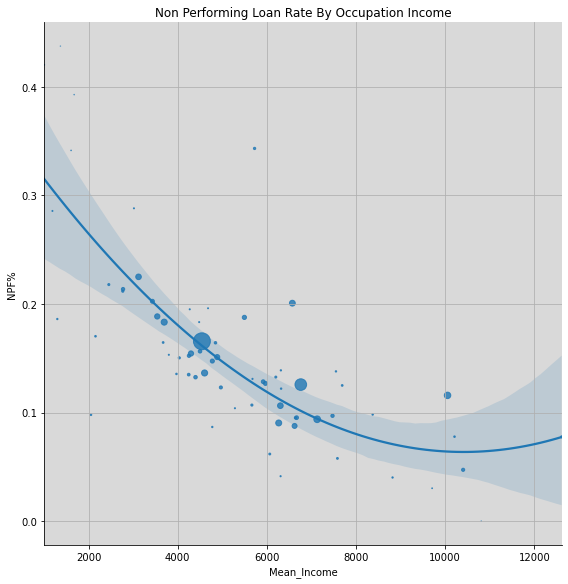

```python
sb.lmplot(x="Mean_Income", y="NPF%", order=2, scatter_kws={'s':occupation_loan_status['Total']/100},
          height=8,
          data=occupation_loan_status)
plt.title('Non Performing Loan Rate By Occupation Income')
plt.grid(True)
ax=plt.gca()
ax.set_facecolor([0.85, 0.85, 0.85])
save_fig('Non_Performing_Loan_Rate_By_Occupation_Income');
```

### Talk about some of the relationships you observed in this part of the investigation. Were there features that strengthened each other in terms of looking at your feature(s) of interest?

I further explored the borrower APR against prosper rating with term effects. The multivariate exploration showed that APR percentage decreases along with the contract term increase from prosper rating HR to C, and then make a twist from rating B to AA, where the APR percentage increases along with the contract term increases.

### Were there any interesting or surprising interactions between features?

The occupation income shows a strong effect on loan status. Borrowers with lower income in their occupation are more likely to fail the repayment, while people with more income are less likely to fail the payment.